# Significance testing for gene espression (RNAseq)

last changed: 2023-08-29

# Sample coverage

## Generate DESeq data set

First, the new coverage file is loaded using `read.table`. Then, the columns which contain the information about the gene expression are filtered . Next, the gene ID’s are added as row names.

```r
> m.raw <- read.table("./Data/count_table.txt", header = T)
> head(m.raw)
```

```
##            Geneid                               Chr
## 1 ENSG00000243485                         1;1;1;1;1
## 2 ENSG00000237613                         1;1;1;1;1
## 3 ENSG00000186092                           1;1;1;1
## 4 ENSG00000238009 1;1;1;1;1;1;1;1;1;1;1;1;1;1;1;1;1
## 5 ENSG00000239945                               1;1
## 6 ENSG00000241599                               1;1
##                                                                                                                 Start
## 1                                                                                       29554;30267;30564;30976;30976
## 2                                                                                       34554;35245;35277;35721;35721
## 3                                                                                             65419;65520;69037;69055
## 4 89295;92091;92230;110953;112700;112700;112700;120721;120725;120775;120874;129055;129055;129055;129081;133374;133374
## 5                                                                                                         89551;90287
## 6                                                                                                       160446;161314
##                                                                                                                   End
```

[output cut: 48 more lines]

```r
> m.RNAseq <- m.raw[, 7:ncol(m.raw)]
> rownames(m.RNAseq) <- m.raw$Geneid
> colnames(m.RNAseq) <-
+   str_split_i(colnames(m.RNAseq), "bams.", 2) %>%
+   str_split_i(".Ali", 1)
> colnames(m.RNAseq)[colnames(m.RNAseq) == "Exp1_0"] <- "Exp1_0h"
> colnames(m.RNAseq)[colnames(m.RNAseq) == "Exp2_0"] <- "Exp2_0h"
> head(m.RNAseq)
```

```
##                 Exp1_05h Exp1_0h Exp1_1h Exp1_2h Exp1_4h Exp2_05h Exp2_0h
## ENSG00000243485        0       0       0       0       0        0       0
## ENSG00000237613        0       0       0       0       0        0       0
## ENSG00000186092        0       0       0       0       0        0       0
## ENSG00000238009        0       0       0       0       0        0       0
## ENSG00000239945        0       0       0       0       0        0       0
## ENSG00000241599        0       0       0       0       0        0       0
##                 Exp2_1h Exp2_2h Exp2_4h
## ENSG00000243485       0       0       0
## ENSG00000237613       0       0       0
## ENSG00000186092       0       0       0
## ENSG00000238009       0       0       1
## ENSG00000239945       0       0       0
## ENSG00000241599       0       0       0
```

For generating a DESeq data set a `colData` file is required containing information about the experiment. Note that the parameter `time` is required to be `numeric` which is essential for a meaningful significance testing. Furthermore, the sample Exp2_0h was dropped, due to being an outlier. The required information were gathered in a matrix. The matrix and count data were then ordered for the parameter `Time` and `replica`.

```r
> info.RNAseq <- read.csv2("./Data/exp_design.csv")
> rownames(info.RNAseq) <- info.RNAseq$ID
> rownames(info.RNAseq)[rownames(info.RNAseq) == "Exp1_0"] <- "Exp1_0h"
> rownames(info.RNAseq)[rownames(info.RNAseq) == "Exp2_0"] <- "Exp2_0h"
> info.RNAseq$replica <- as.factor(info.RNAseq$replica)
> info.RNAseq$Time <- as.double(info.RNAseq$Time)
> paged_table(info.RNAseq)
```

|  | ID | name | condition | replica | Time |
| --- | --- | --- | --- | --- | --- |
| Exp1_05h | Exp1_05h | Exp1_05h | 0.5hpi | R1 | 0.5 |
| Exp1_0h | Exp1_0 | Exp1_0 | 0hpi | R1 | 0.0 |
| Exp1_1h | Exp1_1h | Exp1_1h | 1hpi | R1 | 1.0 |
| Exp1_2h | Exp1_2h | Exp1_2h | 2hpi | R1 | 2.0 |
| Exp1_4h | Exp1_4h | Exp1_4h | 4hpi | R1 | 4.0 |
| Exp2_05h | Exp2_05h | Exp2_05h | 0.5hpi | R2 | 0.5 |
| Exp2_0h | Exp2_0 | Exp2_0 | 0hpi | R2 | 0.0 |
| Exp2_1h | Exp2_1h | Exp2_1h | 1hpi | R2 | 1.0 |
| Exp2_2h | Exp2_2h | Exp2_2h | 2hpi | R2 | 2.0 |
| Exp2_4h | Exp2_4h | Exp2_4h | 4hpi | R2 | 4.0 |

```r
> m.RNAseq <- subset(m.RNAseq, select = -Exp2_0h)
> info.RNAseq <- info.RNAseq[-which(rownames(info.RNAseq) == "Exp2_0h"), ]
>
> colData.RNAseq <- arrange(info.RNAseq, Time, replica)
> paged_table(colData.RNAseq)
```

|  | ID | name | condition | replica | Time |
| --- | --- | --- | --- | --- | --- |
| Exp1_0h | Exp1_0 | Exp1_0 | 0hpi | R1 | 0.0 |
| Exp1_05h | Exp1_05h | Exp1_05h | 0.5hpi | R1 | 0.5 |
| Exp2_05h | Exp2_05h | Exp2_05h | 0.5hpi | R2 | 0.5 |
| Exp1_1h | Exp1_1h | Exp1_1h | 1hpi | R1 | 1.0 |
| Exp2_1h | Exp2_1h | Exp2_1h | 1hpi | R2 | 1.0 |
| Exp1_2h | Exp1_2h | Exp1_2h | 2hpi | R1 | 2.0 |
| Exp2_2h | Exp2_2h | Exp2_2h | 2hpi | R2 | 2.0 |
| Exp1_4h | Exp1_4h | Exp1_4h | 4hpi | R1 | 4.0 |
| Exp2_4h | Exp2_4h | Exp2_4h | 4hpi | R2 | 4.0 |

```r
> m.RNAseq <- m.RNAseq[ ,rownames(colData.RNAseq)]
> head(m.RNAseq)
```

```
##                 Exp1_0h Exp1_05h Exp2_05h Exp1_1h Exp2_1h Exp1_2h Exp2_2h
## ENSG00000243485       0        0        0       0       0       0       0
## ENSG00000237613       0        0        0       0       0       0       0
## ENSG00000186092       0        0        0       0       0       0       0
## ENSG00000238009       0        0        0       0       0       0       0
## ENSG00000239945       0        0        0       0       0       0       0
## ENSG00000241599       0        0        0       0       0       0       0
##                 Exp1_4h Exp2_4h
## ENSG00000243485       0       0
## ENSG00000237613       0       0
## ENSG00000186092       0       0
## ENSG00000238009       0       1
## ENSG00000239945       0       0
## ENSG00000241599       0       0
```

Now that we have all required files, the DESeq data set can be constructed and the parameter `design` takes the variables of the underlying model.

```r
> RNAseq.coverage <- DESeqDataSetFromMatrix(m.RNAseq,
+                                      colData.RNAseq,
+                                      design = ~ Time)
> head(RNAseq.coverage)
```

```
## class: DESeqDataSet
## dim: 6 9
## metadata(1): version
## assays(1): counts
## rownames(6): ENSG00000243485 ENSG00000237613 ... ENSG00000239945
##   ENSG00000241599
## rowData names(0):
## colnames(9): Exp1_0h Exp1_05h ... Exp1_4h Exp2_4h
## colData names(5): ID name condition replica Time
```

```r
> saveRDS(RNAseq.coverage, file = "./Data/raw_RNAseq.rds")
```

## Regularized-log transformation and PCA

Next, the data was scaled using the `rlog` transformation to stabilize the data against variance within the data.

```r
> rlog.RNAseq <- rlog(RNAseq.coverage, blind = F)
> head(rlog.RNAseq)
```

```
## class: DESeqTransform
## dim: 6 9
## metadata(1): version
## assays(1): ''
## rownames(6): ENSG00000243485 ENSG00000237613 ... ENSG00000239945
##   ENSG00000241599
## rowData names(7): baseMean baseVar ... dispFit rlogIntercept
## colnames(9): Exp1_0h Exp1_05h ... Exp1_4h Exp2_4h
## colData names(6): ID name ... Time sizeFactor
```

```r
> saveRDS(rlog.RNAseq, file = "./Data/rlog_RNAseq.rds")
```

To validate the data the rlog-transformed data was used to plot a principal component analysis (PCA) and a heatmap with hierachial clustering.

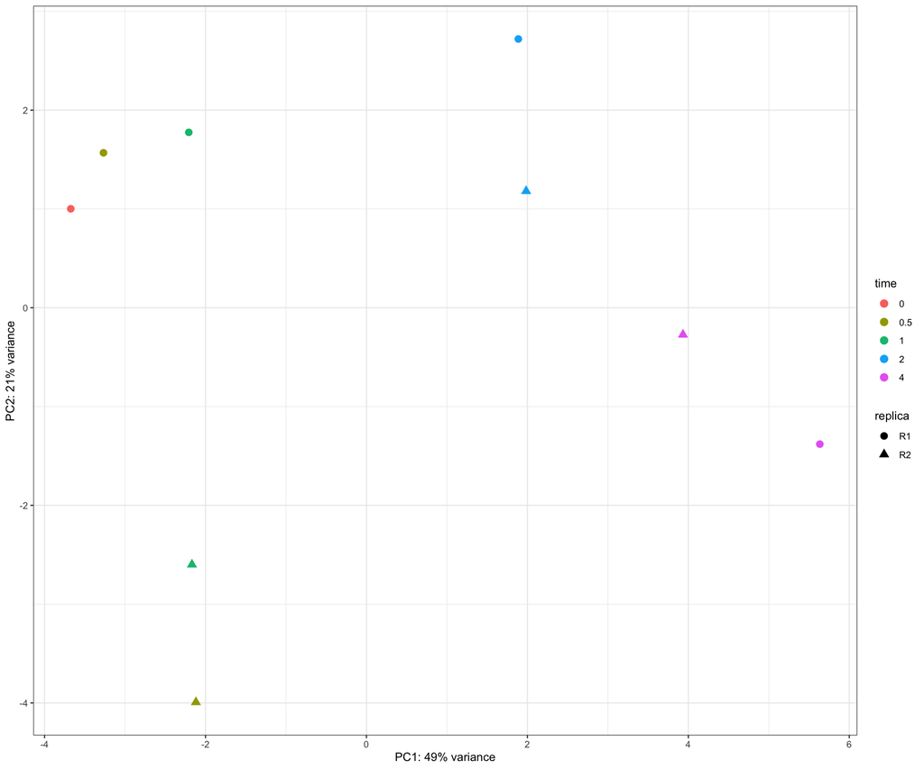

```r
> pca.RNAseq <- plotPCA(rlog.RNAseq,
+                     intgroup = c("replica", "Time"),
+                     returnData = T)
> per.Var <- round(100 * attr(pca.RNAseq, "percentVar"))
>
> ggplot(pca.RNAseq, aes(PC1, PC2, color = Time %>% as.factor(), shape = replica, label = name)) +
+   geom_point(size = 3) +
+   labs(x = paste0("PC1: ", per.Var[1], "% variance"),
+        y = paste0("PC2: ", per.Var[2], "% variance"),
+        color = "time",
+        main = "PCA for RNAseq after infection in hours") +
+   theme_bw()
```

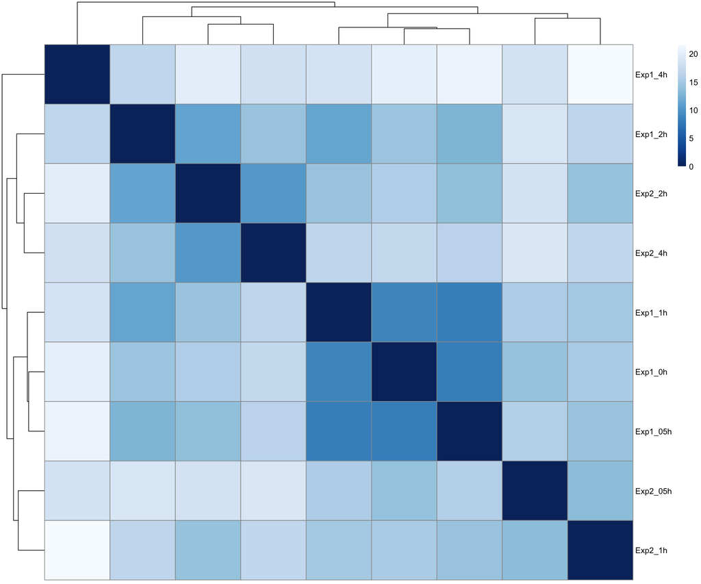

```r
> sample.dist <- dist(t(assay(rlog.RNAseq)))
> m.dist <- sample.dist %>% as.matrix()
> colnames(m.dist) <- NULL
>
> col <- colorRampPalette( rev(brewer.pal(9, "Blues")) )(255)
>
> plot.heat <- pheatmap(m.dist,
+                       clustering_distance_rows = sample.dist,
+                       clustering_distance_cols = sample.dist,
+                       col = col)
```

## Significance testing (Likelihood ratio test - LRT)

To find significant changes in gene expression a likelihood ratio test (LRT) was used. This test compares 2 models, the full model (M ~ time) and the simpler model (M(s) ~ 1). This results in genes which show significant difference between those 2 models, in this case only genes which significantly affect the larger model will score a low enough p-values. The output was then used to filter the rlog data for significant peaks (adjusted p value <= 0.05).

```r
> RNAseq.LRT <- DESeq(RNAseq.coverage, test = "LRT", reduced = ~ 1)
> head(RNAseq.LRT)
```

```
## class: DESeqDataSet
## dim: 6 9
## metadata(1): version
## assays(4): counts mu H cooks
## rownames(6): ENSG00000243485 ENSG00000237613 ... ENSG00000239945
##   ENSG00000241599
## rowData names(21): baseMean baseVar ... deviance maxCooks
## colnames(9): Exp1_0h Exp1_05h ... Exp1_4h Exp2_4h
## colData names(6): ID name ... Time sizeFactor
```

```r
> saveRDS(RNAseq.LRT, file = "./Data/LRT_RNAseq_sig.rds")
>
> res <- results(RNAseq.LRT)
> head(res)
```

```
## log2 fold change (MLE): Time
## LRT p-value: '~ Time' vs '~ 1'
## DataFrame with 6 rows and 6 columns
##                  baseMean log2FoldChange     lfcSE      stat    pvalue
##                 <numeric>      <numeric> <numeric> <numeric> <numeric>
## ENSG00000243485  0.000000             NA        NA        NA        NA
## ENSG00000237613  0.000000             NA        NA        NA        NA
## ENSG00000186092  0.000000             NA        NA        NA        NA
## ENSG00000238009  0.159601       0.571584   1.19461  0.393281   0.53058
## ENSG00000239945  0.000000             NA        NA        NA        NA
## ENSG00000241599  0.000000             NA        NA        NA        NA
##                      padj
##                 <numeric>
## ENSG00000243485        NA
## ENSG00000237613        NA
## ENSG00000186092        NA
## ENSG00000238009        NA
## ENSG00000239945        NA
## ENSG00000241599        NA
```

```r
> res.sig <- res[which(res$padj <= 0.05), ]
>
> rlog.RNAseq.sig <- rlog.RNAseq[rownames(res.sig), ]
>
> saveRDS(rlog.RNAseq.sig, file = "./Data/rlog_RNAseq_sig.rds")
```

## References - packages

- Ahlmann-Eltze C, Hickey P, Pagès H (2023). *MatrixGenerics: S4 Generic Summary Statistic Functions that Operate on Matrix-Like Objects*. doi:10.18129/B9.bioc.MatrixGenerics https://doi.org/10.18129/B9.bioc.MatrixGenerics, R package version 1.12.2, https://bioconductor.org/packages/MatrixGenerics.
- Allaire J, Xie Y, Dervieux C, McPherson J, Luraschi J, Ushey K, Atkins A, Wickham H, Cheng J, Chang W, Iannone R (2023). *rmarkdown: Dynamic Documents for R*. R package version 2.23, https://github.com/rstudio/rmarkdown. Xie Y, Allaire J, Grolemund G (2018). *R Markdown: The Definitive Guide*. Chapman and Hall/CRC, Boca Raton, Florida. ISBN 9781138359338, https://bookdown.org/yihui/rmarkdown. Xie Y, Dervieux C, Riederer E (2020). *R Markdown Cookbook*. Chapman and Hall/CRC, Boca Raton, Florida. ISBN 9780367563837, https://bookdown.org/yihui/rmarkdown-cookbook.
- Arora S, Morgan M, Carlson M, Pagès H (2023). *GenomeInfoDb: Utilities for manipulating chromosome names, including modifying them to follow a particular naming style*. doi:10.18129/B9.bioc.GenomeInfoDb https://doi.org/10.18129/B9.bioc.GenomeInfoDb, R package version 1.36.0, https://bioconductor.org/packages/GenomeInfoDb.
- Bengtsson H (2023). *matrixStats: Functions that Apply to Rows and Columns of Matrices (and to Vectors)*. R package version 1.0.0, https://CRAN.R-project.org/package=matrixStats.
- Huber W, Carey VJ, Gentleman R, Anders S, Carlson M, Carvalho BS, Bravo HC, Davis S, Gatto L, Girke T, Gottardo R, Hahne F, Hansen KD, Irizarry RA, Lawrence M, Love MI, MacDonald J, Obenchain V, Ole’s AK, Pag`es H, Reyes A, Shannon P, Smyth GK, Tenenbaum D, Waldron L, Morgan M (2015). “Orchestrating high-throughput genomic analysis with Bioconductor.” *Nature Methods*, *12*(2), 115-121. http://www.nature.com/nmeth/journal/v12/n2/full/nmeth.3252.html.
- Huber, W., Carey, J. V, Gentleman, R., Anders, S., Carlson, M., Carvalho, S. B, Bravo, C. H, Davis, S., Gatto, L., Girke, T., Gottardo, R., Hahne, F., Hansen, D. K, Irizarry, A. R, Lawrence, M., Love, I. M, MacDonald, J., Obenchain, V., Ole’s, K. A, Pag`es, H., Reyes, A., Shannon, P., Smyth, K. G, Tenenbaum, D., Waldron, L., Morgan, M. (2015). “Orchestrating high-throughput genomic analysis with Bioconductor.” *Nature Methods*, *12*(2), 115-121. http://www.nature.com/nmeth/journal/v12/n2/full/nmeth.3252.html.
- Kolde R (2019). *pheatmap: Pretty Heatmaps*. R package version 1.0.12, https://CRAN.R-project.org/package=pheatmap.
- Lawrence M, Huber W, Pagès H, Aboyoun P, Carlson M, Gentleman R, Morgan M, Carey V (2013). “Software for Computing and Annotating Genomic Ranges.” *PLoS Computational Biology*, *9*. doi:10.1371/journal.pcbi.1003118 https://doi.org/10.1371/journal.pcbi.1003118, http://www.ploscompbiol.org/article/info%3Adoi%2F10.1371%2Fjournal.pcbi.1003118.
- Lawrence M, Huber W, Pagès H, Aboyoun P, Carlson M, Gentleman R, Morgan M, Carey V (2013). “Software for Computing and Annotating Genomic Ranges.” *PLoS Computational Biology*, *9*. doi:10.1371/journal.pcbi.1003118 https://doi.org/10.1371/journal.pcbi.1003118, http://www.ploscompbiol.org/article/info%3Adoi%2F10.1371%2Fjournal.pcbi.1003118.
- Love MI, Huber W, Anders S (2014). “Moderated estimation of fold change and dispersion for RNA-seq data with DESeq2.” *Genome Biology*, *15*, 550. doi:10.1186/s13059-014-0550-8 https://doi.org/10.1186/s13059-014-0550-8.
- Makowski D, Lüdecke D, Patil I, Thériault R, Ben-Shachar M, Wiernik B (2023). “Automated Results Reporting as a Practical Tool to Improve Reproducibility and Methodological Best Practices Adoption.” *CRAN*. https://easystats.github.io/report/.
- Morgan M, Obenchain V, Hester J, Pagès H (2023). *SummarizedExperiment: SummarizedExperiment container*. doi:10.18129/B9.bioc.SummarizedExperiment https://doi.org/10.18129/B9.bioc.SummarizedExperiment, R package version 1.30.2, https://bioconductor.org/packages/SummarizedExperiment.
- Neuwirth E (2022). *RColorBrewer: ColorBrewer Palettes*. R package version 1.1-3, https://CRAN.R-project.org/package=RColorBrewer.
- Pagès H, Lawrence M, Aboyoun P (2023). *S4Vectors: Foundation of vector-like and list-like containers in Bioconductor*. doi:10.18129/B9.bioc.S4Vectors https://doi.org/10.18129/B9.bioc.S4Vectors, R package version 0.38.1, https://bioconductor.org/packages/S4Vectors.
- R Core Team (2023). *R: A Language and Environment for Statistical Computing*. R Foundation for Statistical Computing, Vienna, Austria. https://www.R-project.org/.
- Wickham H (2016). *ggplot2: Elegant Graphics for Data Analysis*. Springer-Verlag New York. ISBN 978-3-319-24277-4, https://ggplot2.tidyverse.org.
- Wickham H (2022). *stringr: Simple, Consistent Wrappers for Common String Operations*. R package version 1.5.0, https://CRAN.R-project.org/package=stringr.
- Wickham H, François R, Henry L, Müller K, Vaughan D (2023). *dplyr: A Grammar of Data Manipulation*. R package version 1.1.2, https://CRAN.R-project.org/package=dplyr.
- Xie Y (2023). *knitr: A General-Purpose Package for Dynamic Report Generation in R*. R package version 1.43, https://yihui.org/knitr/. Xie Y (2015). *Dynamic Documents with R and knitr*, 2nd edition. Chapman and Hall/CRC, Boca Raton, Florida. ISBN 978-1498716963, https://yihui.org/knitr/. Xie Y (2014). “knitr: A Comprehensive Tool for Reproducible Research in R.” In Stodden V, Leisch F, Peng RD (eds.), *Implementing Reproducible Computational Research*. Chapman and Hall/CRC. ISBN 978-1466561595.